# P&C Pricing Tutorial

## Pricing Example

I have created this document to show the work I have done and as a first starting point for discussion. Any suggestions or advice is, of course, more than welcome.

The outline of the document is as follows:

1. Import and description of the dataset
2. One-Way tables and KPI
3. Fit Frequency Model
4. Fit Severity Model
5. Combine the models
6. Evaluate Performances
7. Future Improvements

# Import the data

The dataset used for modeling is the dataset that can be created using the script `data-fetch.R`, `data-prep.R` and `feature-engineering.R` from the main repository. For simplicity I included the dataset as an RDS file in this repository, `modeling_data.RDS`

The data can therefore be imported with the command:

```r
modeling_data <- readRDS("./modeling_data.RDS") %>% ungroup() %>% na.omit()
```

I am also ungrouping the dataset and deleting any observation with NAs. The dataset comes from a grouping process and therefore it is handy to ungroup it since in the analysis I will modify grouping variables. This operation would not be allowed on a grouped dataframe.

We can check that all the operation performed as expected:

```r
map(modeling_data, ~sum(is.na(.)))
```

```
## $region
## [1] 0
##
## $sex
## [1] 0
##
## $age_range
## [1] 0
##
## $vehicle_age
## [1] 0
##
## $make
## [1] 0
##
## $vehicle_category
## [1] 0
##
## $exposure
## [1] 0
##
## $claim_amount
## [1] 0
##
## $claim_count
## [1] 0
```

Once the data is imported we can perform some exploratory analysis.

# One-Way Tables and KPIs

The first operation we will perform is to check if there are any levels with low exposure and all the classes are balanced. I am only considering factor predictors.

```r
map(select(modeling_data, -c(vehicle_age, exposure, claim_amount, claim_count)), ~table(.))
```

```
## $region
## .
##                                       AC - Acre
##                                            2764
##                                    AL - Alagoas
##                                            6366
##                                   AM - Amazonas
##                                            5419
##                                      AP - Amapá
##                                            2108
##                                      BA - Bahia
##                                           11065
##                                      CE - Ceará
##                                            8939
##                                   DF - Brasília
##                                            9799
##                             ES - Espírito Santo
##                                            9761
##                                      GO - Goiás
##                                           10356
##                           GO - Sudeste de Goiás
##                                            5014
##                                   MA - Maranhão
##                                            6030
## MG - Met.BH-Centro Oeste-Zona Mata-C. Vertentes
##                                           14232
##                                        MG - Sul
##                                            9725
##                          MG - Triângulo mineiro
##                                           10960
##       MG - Vale do Aço-Norte-Vale Jequitinhonha
##                                            6579
##                         MS - Mato Grosso do Sul
##                                            8704
##                                MT - Mato Grosso
##                                            8596
##                                       PA - Pará
##                                            7063
##                                    PB - Paraíba
##                                            6465
```

[output cut: 73 more lines]

```
##                                   24146
##           Ônibus (nacional e importado)
##                                    3411
##                                  Outros
##                                   18504
##                       Passeio importado
##                                   78245
##                        Passeio nacional
##                                  118664
##          Pick-up (nacional e importado)
##                                   95372
##      Utilitários (nacional e importado)
##                                    3920
## Veículo de Carga (nacional e importado)
##                                   46105
```

Let’s now evaluate actuarial KPIs for each predictor:

`region`, `sex`, `age_range`, `vehicle_age`, `make`, `vehicle_category`

```
## # A tibble: 42 x 7
##    region                exposure   amounts numbers    lc  freq   sev
##    <fct>                    <dbl>     <dbl>   <dbl> <dbl> <dbl> <dbl>
##  1 AC - Acre                6670    5478323    1338  821. 0.201 4094.
##  2 AL - Alagoas            51956.  40331443    8162  776. 0.157 4941.
##  3 AM - Amazonas           30080   20441172    5771  680. 0.192 3542.
##  4 AP - Amapá               4288.   2690357     562  627. 0.131 4787.
##  5 BA - Bahia             255620  211475059   48360  827. 0.189 4373.
##  6 CE - Ceará             126476.  83598461   21738  661. 0.172 3846.
##  7 DF - Brasília          193863  131960940   42548  681. 0.219 3101.
##  8 ES - Espírito Santo    118896. 100518348   27808  845. 0.234 3615.
##  9 GO - Goiás             208920. 174617047   40263  836. 0.193 4337.
## 10 GO - Sudeste de Goiás   21759   21506963    3393  988. 0.156 6339.
## # … with 32 more rows
```

```
## # A tibble: 4 x 7
##   sex            exposure    amounts numbers     lc  freq   sev
##   <fct>             <dbl>      <dbl>   <dbl>  <dbl> <dbl> <dbl>
## 1 Feminino       2831881  2002872945  767137   707. 0.271 2611.
## 2 Jurídica        938146.          0       0     0  0        0
## 3 Masculino      3425436  2883541952  883549   842. 0.258 3264.
## 4 Sem Informação   50022.  719436995  135667 14382. 2.71  5303.
```

```
## # A tibble: 6 x 7
##   age_range          exposure    amounts numbers    lc  freq   sev
##   <fct>                 <dbl>      <dbl>   <dbl> <dbl> <dbl> <dbl>
## 1 Entre 18 e 25 anos  260722.  234497150   58016  899. 0.223 4042.
## 2 Entre 26 e 35 anos 1446656. 1169970980  342076  809. 0.236 3420.
## 3 Entre 36 e 45 anos 1591338. 1203931825  404622  757. 0.254 2975.
## 4 Entre 46 e 55 anos 1531898. 1129765424  397577  737. 0.260 2842.
## 5 Maior que 55 anos  1603678. 1039549034  458443  648. 0.286 2268.
## 6 Não informada       811194.  828137479  125619 1021. 0.155 6592.
```

```
## # A tibble: 36 x 7
##    vehicle_age exposure    amounts numbers    lc  freq   sev
##          <dbl>    <dbl>      <dbl>   <dbl> <dbl> <dbl> <dbl>
##  1           0 1028590.  851055099  186674  827. 0.181 4559.
##  2           1 1361562. 1219702619  297536  896. 0.219 4099.
##  3           2 1150088.  980755706  287491  853. 0.250 3411.
##  4           3  814422.  638516990  213527  784. 0.262 2990.
##  5           4  805592.  624426159  216654  775. 0.269 2882.
##  6           5  470036   348761906  130935  742. 0.279 2664.
##  7           6  318891   226712484   85185  711. 0.267 2661.
##  8           7  287514.  187017855   78298  650. 0.272 2389.
##  9           8  209288.  134723044   56271  644. 0.269 2394.
## 10           9  173414.  101334379   47608  584. 0.275 2129.
## # … with 26 more rows
```

```
## # A tibble: 18 x 7
##    make          exposure   amounts numbers    lc  freq   sev
##    <fct>            <dbl>     <dbl>   <dbl> <dbl> <dbl> <dbl>
##  1 CITROEN        158310. 109787844   48844  693. 0.309 2248.
##  2 FIAT          1071960. 656600363  245272  613. 0.229 2677.
##  3 FORD           753549  499096738  191720  662. 0.254 2603.
##  4 GM            1191984. 673518979  331965  565. 0.278 2029.
##  5 HONDA          305791  242687931   94505  794. 0.309 2568.
##  6 HYUNDAI         90249   88283832   28945  978. 0.321 3050.
##  7 KIA             57347   55900960   13645  975. 0.238 4097.
##  8 MERCEDES-BENZ   95606. 173431095   18530 1814. 0.194 9359.
##  9 MITSUBISHI      83572. 126579823   21111 1515. 0.253 5996.
## 10 NISSAN          47847   53366474    9776 1115. 0.204 5459.
## 11 OUTROS         334181  377009800   46351 1128. 0.139 8134.
## 12 PEUGEOT        194184  137219104   58082  707. 0.299 2363.
## 13 RENAULT        288099  178949041   74511  621. 0.259 2402.
## 14 TOYOTA         212873  249670682   47964 1173. 0.225 5205.
## 15 VOLKSWAGEN      56418. 105920938   11080 1877. 0.196 9560.
## 16 VW            1118432. 723662383  257964  647. 0.231 2805.
## 17 other          157810  315822592   43282 2001. 0.274 7297.
## 18 (Missing)     1027272. 838343313  242806  816. 0.236 3453.
```

```
## # A tibble: 8 x 7
##   vehicle_category            exposure  amounts numbers    lc   freq    sev
##   <fct>                          <dbl>    <dbl>   <dbl> <dbl>  <dbl>  <dbl>
## 1 Motocicleta (nacional e im…  197802.   1.23e8   34917  623. 0.177   3531.
## 2 Ônibus (nacional e importa…    5988    1.26e6     970  210. 0.162   1296.
## 3 Outros                        73388    2.45e8    9647 3343. 0.131  25435.
## 4 Passeio importado            859444.   8.36e8  132204  973. 0.154   6326.
## 5 Passeio nacional            5036280.   3.16e9 1361241  628. 0.270   2324.
## 6 Pick-up (nacional e import…  861372.   8.94e8  211888 1038. 0.246   4221.
## 7 Utilitários (nacional e im…    4442.   2.78e6     336  627. 0.0757  8287.
## 8 Veículo de Carga (nacional…  206772.   3.40e8   35150 1642. 0.170   9661.
```

and the relative plots:

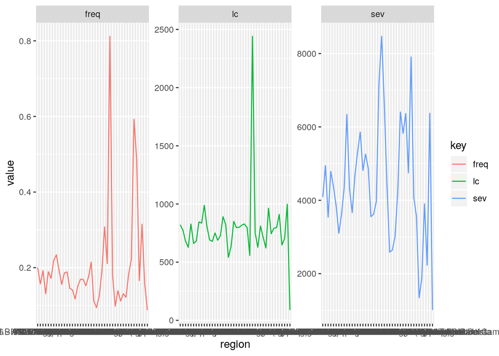

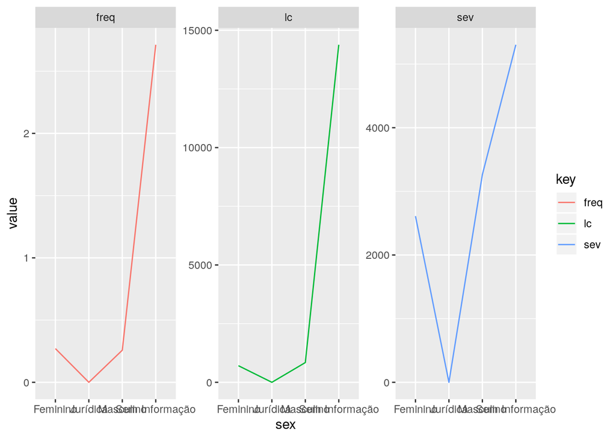

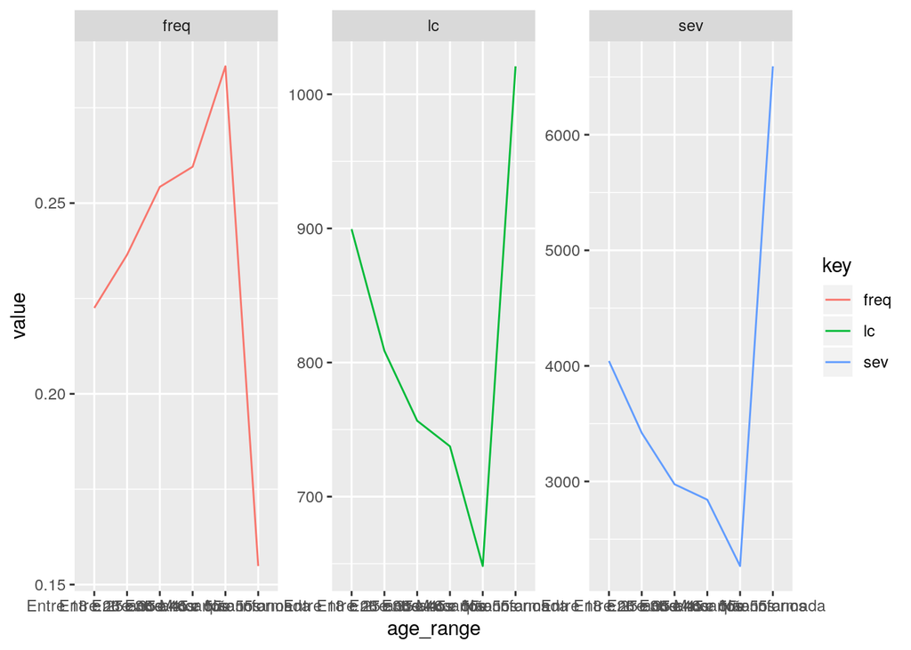

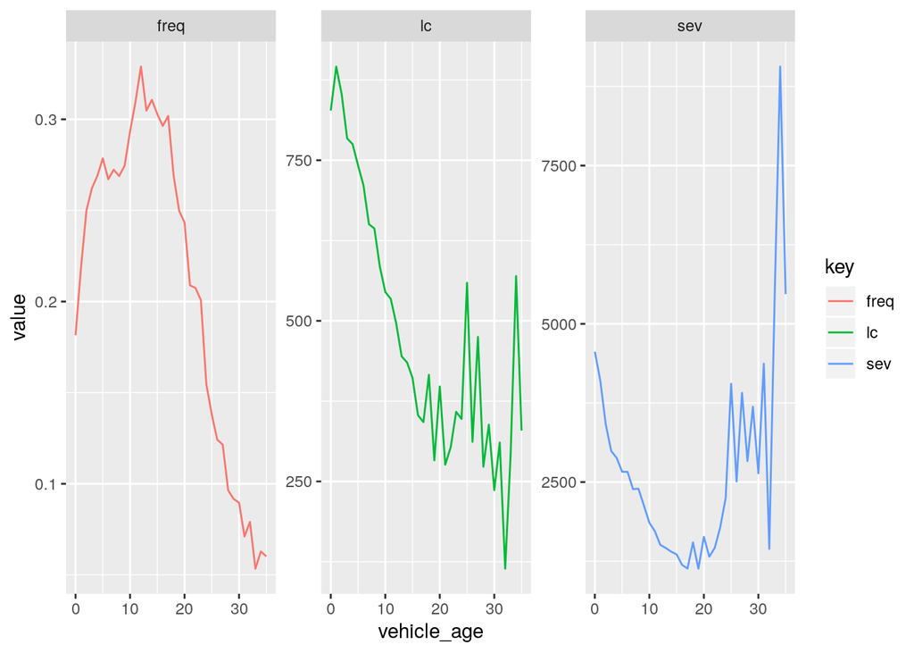

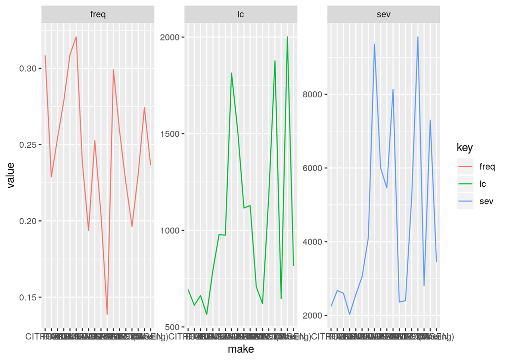

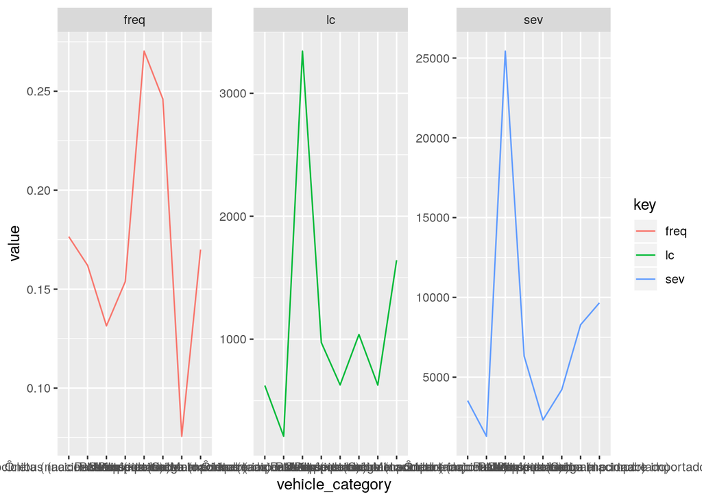

At this point we can divide the dataset in train/test (.8, .2) and add the necessary variables:

```r
modeling_data <- modeling_data %>%
                 mutate(sev = if_else(claim_count == 0, 0, claim_amount / claim_count),
                        lc = claim_amount / exposure) %>%
                 mutate(id = row_number())

train_data <- modeling_data %>% sample_frac(.8)

test_data <- modeling_data %>% anti_join(train_data, by = "id")
```

We can now start the modeling process.

# Fit Frequency Model

The first model we are going to fit is the frequncy model.

This model will be a GLM with target variable `claim count`

```r
freq_model <- glm(claim_count ~ region + sex + age_range + vehicle_age + make +
                    vehicle_category + offset(log(exposure)),
                  family = poisson(link = "log"),
                  data = train_data
                  )

summary(freq_model)
```

```
##
## Call:
## glm(formula = claim_count ~ region + sex + age_range + vehicle_age +
##     make + vehicle_category + offset(log(exposure)), family = poisson(link = "log"),
##     data = train_data)
##
## Deviance Residuals:
##     Min       1Q   Median       3Q      Max
## -26.426   -0.668   -0.281    0.000  176.939
##
## Coefficients:
##                                                           Estimate
## (Intercept)                                              -1.704379
## regionAL - Alagoas                                       -0.187066
## regionAM - Amazonas                                       0.024888
## regionAP - Amapá                                         -0.309249
## regionBA - Bahia                                          0.011737
## regionCE - Ceará                                         -0.081557
## regionDF - Brasília                                       0.089415
## regionES - Espírito Santo                                 0.139948
## regionGO - Goiás                                          0.003526
## regionGO - Sudeste de Goiás                              -0.305386
## regionMA - Maranhão                                       0.001691
## regionMG - Met.BH-Centro Oeste-Zona Mata-C. Vertentes     0.017244
## regionMG - Sul                                           -0.358932
## regionMG - Triângulo mineiro                             -0.403771
## regionMG - Vale do Aço-Norte-Vale Jequitinhonha          -0.575147
## regionMS - Mato Grosso do Sul                            -0.282525
## regionMT - Mato Grosso                                   -0.161411
## regionPA - Pará                                          -0.130645
## regionPB - Paraíba                                       -0.266529
## regionPE - Pernambuco                                    -0.089010
## regionPI - Piaui                                          0.121351
## regionPR - Demais regiões                                -0.616062
## regionPR - F.Iguaþu-Medianeira-Cascavel-Toledo           -0.734112
## regionPR - Met. Curitiba                                 -0.473039
## regionRJ - Interior                                      -0.100861
## regionRJ - Met. do Rio de Janeiro                         0.421146
## regionRN - Rio Grande do Norte                            0.066384
## regionRO - Rondônia                                       1.126434
```

[output cut: 194 more lines]

```
## vehicle_categoryPasseio importado                        < 2e-16 ***
## vehicle_categoryPasseio nacional                         < 2e-16 ***
## vehicle_categoryPick-up (nacional e importado)           < 2e-16 ***
## vehicle_categoryUtilitários (nacional e importado)       < 2e-16 ***
## vehicle_categoryVeículo de Carga (nacional e importado)  < 2e-16 ***
## ---
## Signif. codes:  0 '***' 0.001 '**' 0.01 '*' 0.05 '.' 0.1 ' ' 1
##
## (Dispersion parameter for poisson family taken to be 1)
##
##     Null deviance: 1839833  on 310693  degrees of freedom
## Residual deviance:  591699  on 310619  degrees of freedom
## AIC: 918664
##
## Number of Fisher Scoring iterations: 18
```

```r
anova(freq_model)
```

```
## Analysis of Deviance Table
##
## Model: poisson, link: log
##
## Response: claim_count
##
## Terms added sequentially (first to last)
##
##
##                  Df Deviance Resid. Df Resid. Dev
## NULL                            310693    1839833
## region           41   400497    310652    1439337
## sex               3   721022    310649     718314
## age_range         5    68248    310644     650066
## vehicle_age       1      258    310643     649808
## make             17    11734    310626     638074
## vehicle_category  7    46375    310619     591699
```

# Fit Severity Model

Similarly, we fit a glm for the severity.

Here the variable target will be `sev`.

In this case, the variable `sex` has not been included, since the level `Juridica` does not have any claims.

```r
sev_model <- glm(sev ~ region + age_range + vehicle_age + make +
                    vehicle_category,
                 family = Gamma(link = "log"),
                 weights = claim_count,
                 data = filter(train_data, claim_count > 0)
)

summary(sev_model)
```

```
##
## Call:
## glm(formula = sev ~ region + age_range + vehicle_age + make +
##     vehicle_category, family = Gamma(link = "log"), data = filter(train_data,
##     claim_count > 0), weights = claim_count)
##
## Deviance Residuals:
##     Min       1Q   Median       3Q      Max
## -97.501   -2.443   -1.107    0.722   30.261
##
## Coefficients:
##                                                          Estimate
## (Intercept)                                              8.486114
## regionAL - Alagoas                                       0.254172
## regionAM - Amazonas                                     -0.052911
## regionAP - Amapá                                         0.047503
## regionBA - Bahia                                         0.186584
## regionCE - Ceará                                        -0.063950
## regionDF - Brasília                                     -0.115731
## regionES - Espírito Santo                                0.006254
## regionGO - Goiás                                         0.099497
## regionGO - Sudeste de Goiás                              0.390155
## regionMA - Maranhão                                     -0.051284
## regionMG - Met.BH-Centro Oeste-Zona Mata-C. Vertentes    0.012670
## regionMG - Sul                                           0.235941
## regionMG - Triângulo mineiro                             0.390609
## regionMG - Vale do Aço-Norte-Vale Jequitinhonha          0.456276
## regionMS - Mato Grosso do Sul                            0.176872
## regionMT - Mato Grosso                                   0.223120
## regionPA - Pará                                          0.182523
## regionPB - Paraíba                                      -0.042359
## regionPE - Pernambuco                                    0.004836
## regionPI - Piaui                                        -0.065722
## regionPR - Demais regiões                                0.628050
## regionPR - F.Iguaþu-Medianeira-Cascavel-Toledo           0.787252
## regionPR - Met. Curitiba                                 0.588534
## regionRJ - Interior                                      0.275634
## regionRJ - Met. do Rio de Janeiro                       -0.234212
## regionRN - Rio Grande do Norte                          -0.348543
## regionRO - Rondônia                                     -0.444065
```

[output cut: 185 more lines]

```
## vehicle_categoryPasseio importado                        < 2e-16 ***
## vehicle_categoryPasseio nacional                        8.10e-15 ***
## vehicle_categoryPick-up (nacional e importado)          6.64e-10 ***
## vehicle_categoryUtilitários (nacional e importado)      0.005325 **
## vehicle_categoryVeículo de Carga (nacional e importado)  < 2e-16 ***
## ---
## Signif. codes:  0 '***' 0.001 '**' 0.01 '*' 0.05 '.' 0.1 ' ' 1
##
## (Dispersion parameter for Gamma family taken to be 17.65602)
##
##     Null deviance: 1730668  on 104657  degrees of freedom
## Residual deviance:  944497  on 104586  degrees of freedom
## AIC: 24939736
##
## Number of Fisher Scoring iterations: 10
```

```r
anova(sev_model)
```

```
## Analysis of Deviance Table
##
## Model: Gamma, link: log
##
## Response: sev
##
## Terms added sequentially (first to last)
##
##
##                  Df Deviance Resid. Df Resid. Dev
## NULL                            104657    1730668
## region           41   290845    104616    1439823
## age_range         5   112129    104611    1327694
## vehicle_age       1    93297    104610    1234397
## make             17   144296    104593    1090102
## vehicle_category  7   145604    104586     944497
```

# Combine the models

It is handy to combine the two models in a single one that predict the loss cost.

This can be done with the following code:

```r
train_data <- train_data %>%
              mutate(pred_numbers = predict(freq_model, newdata = train_data, type = "response"),
                     pred_sev = predict(sev_model, newdata = train_data, type = "response"),
                     pred_lc = pred_numbers * pred_sev / exposure)

lc_model <- glm(pred_lc ~ region + sex + age_range + vehicle_age + make +
                  vehicle_category,
                family = Gamma(link = "log"),
                weights = exposure,
                data = train_data
)
```

This, of course, will lead to the same results as multyplig the frequency adn severity models.

```r
sum(predict(lc_model, newdata = train_data, type = "response"))
```

```
## [1] 597562045
```

```r
sum(train_data$pred_lc)
```

```
## [1] 597562045
```

# Evaluate Performances

We can now evaluate the performances the model has achieved.

The first thing to do is to predict the Loss Cost:

```r
test_data <- test_data %>%
             mutate(pred_lc = predict(lc_model, newdata = test_data, type = "response"))
```

1. NRMSE

```
## [1] 0.01230477
```

2. GINI Index and Plot

```
## [1] 0.8413115
```

And the actual output:

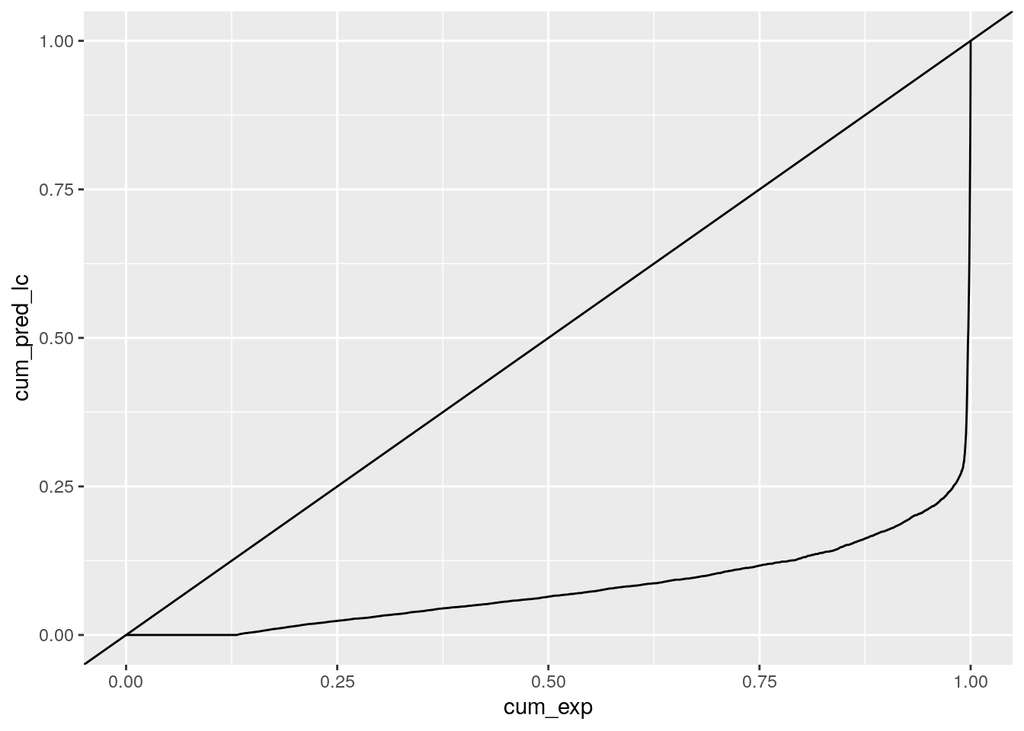

3. Actual vs. Predicted

We can also plot the actual Loss Cost vs the Predicted Loss Cost alongside the exposure for each class.

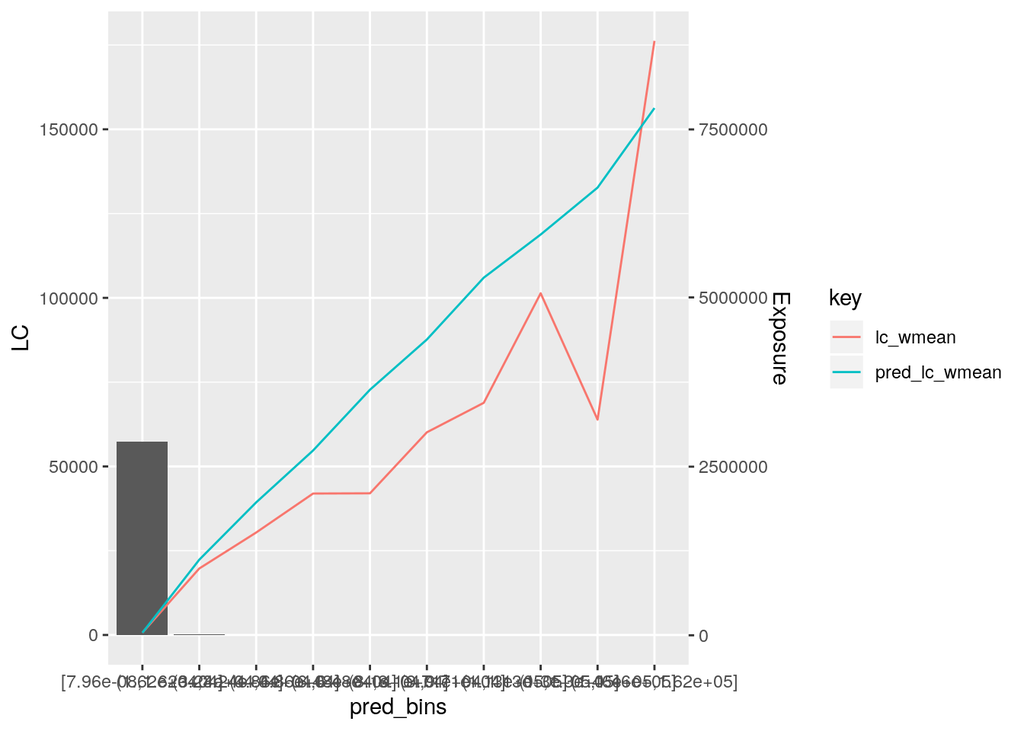

4. Lift Curve

And finally, the lift curve comparing the mean value for each decile.

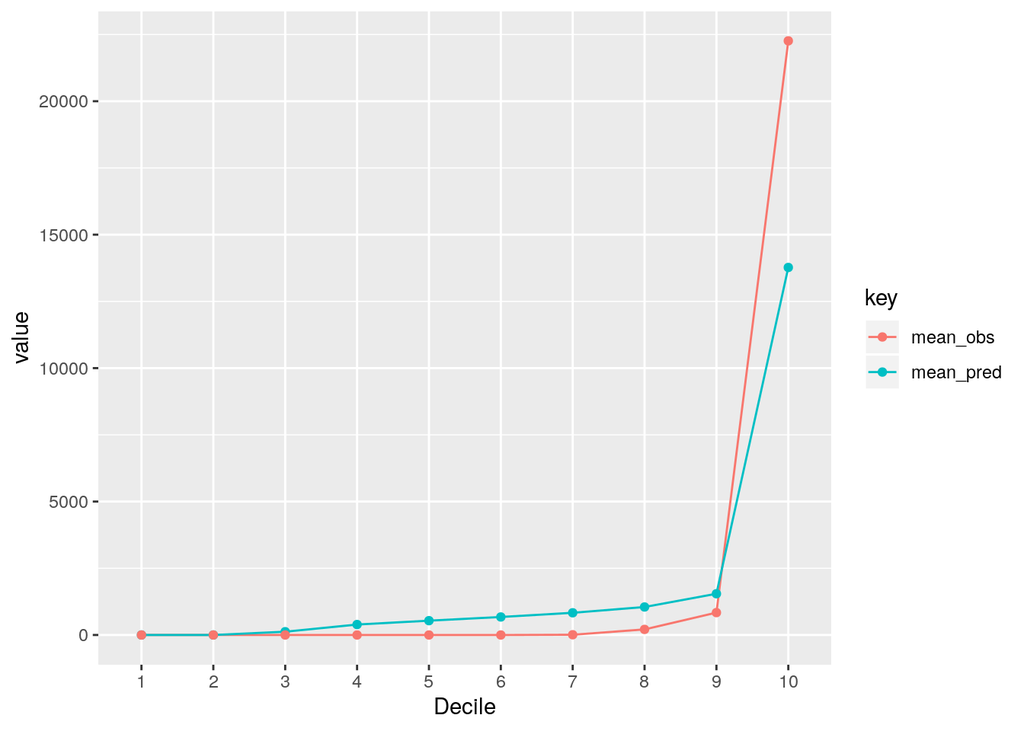

# Future Improvements

As mentioned, this is just a preliminary work. Future improvement could include, estimating relativities, exploring interactions between factors and using splines or any other smoothing function for numerical predictors.